# Context

### Cardiovascular diseases (CVDs) are the number 1 cause of death globally, taking an estimated 17.9 million lives each year, which accounts for 31% of all deaths worldwide. Four out of 5CVD deaths are due to heart attacks and strokes, and one-third of these deaths occur prematurely in people under 70 years of age. Heart failure is a common event caused by CVDs and this dataset contains 11 features that can be used to predict a possible heart disease.

### People with cardiovascular disease or who are at high cardiovascular risk (due to the presence of one or more risk factors such as hypertension, diabetes, hyperlipidaemia or already established disease) need early detection and management wherein a machine learning model can be of great help.

## Attribute Information

### 1. Age: age of the patient [years]

### 2. Sex: sex of the patient [M: Male, F: Female]

### 3. ChestPainType: chest pain type [TA: Typical Angina, ATA: Atypical Angina, NAP: Non-Anginal Pain, ASY: Asymptomatic]

### 4. RestingBP: resting blood pressure [mm Hg]

### 5. Cholesterol: serum cholesterol [mm/dl]

### 6. FastingBS: fasting blood sugar [1: if FastingBS > 120 mg/dl, 0: otherwise]

### 7. RestingECG: resting electrocardiogram results [Normal: Normal, ST: having ST-T wave abnormality (T wave inversions and/or ST elevation or depression of > 0.05 mV), LVH: showing probable or definite left ventricular hypertrophy by Estes' criteria]

### 8. MaxHR: maximum heart rate achieved [Numeric value between 60 and 202]

### 9. ExerciseAngina: exercise-induced angina [Y: Yes, N: No]

### 10. Oldpeak: oldpeak = ST [Numeric value measured in depression]

### 11. ST_Slope: the slope of the peak exercise ST segment [Up: upsloping, Flat: flat, Down: downsloping]

### 12. HeartDisease: output class [1: heart disease, 0: Normal]

# Loading Libraries

```python
import warnings

warnings.filterwarnings("ignore")
from statsmodels.tools.sm_exceptions import ConvergenceWarning

warnings.simplefilter("ignore", ConvergenceWarning)

# Libraries to help with reading and manipulating data

import pandas as pd
import numpy as np

# Library to split data
from sklearn.model_selection import train_test_split

# libaries to help with data visualization
import matplotlib.pyplot as plt
import seaborn as sns

# Removes the limit for the number of displayed columns
pd.set_option("display.max_columns", None)
# Sets the limit for the number of displayed rows
pd.set_option("display.max_rows", 200)


# To build model for prediction
import statsmodels.stats.api as sms
from statsmodels.stats.outliers_influence import variance_inflation_factor
import statsmodels.api as sm
from statsmodels.tools.tools import add_constant
from sklearn.linear_model import LogisticRegression
from sklearn.tree import DecisionTreeClassifier
from sklearn import tree

# To tune different models
from sklearn.model_selection import GridSearchCV


# To get diferent metric scores
from sklearn.metrics import (
    f1_score,
    accuracy_score,
    recall_score,
    precision_score,
    confusion_matrix,
    roc_auc_score,
    plot_confusion_matrix,
    precision_recall_curve,
    roc_curve,
    make_scorer,
)

# To define maximum number of columns to be displayed in a dataframe
pd.set_option("display.max_columns", None)

# To supress scientific notations for a dataframe
pd.set_option("display.float_format", lambda x: "%.3f" % x)
from sklearn.model_selection import GridSearchCV

# To supress warnings
import warnings

warnings.filterwarnings("ignore")

# Removes the limit from the number of displayed columns and rows.
# This is so I can see the entire dataframe when I print it
pd.set_option("display.max_columns", None)
# pd.set_option('display.max_rows', None)
pd.set_option("display.max_rows", 200)
```

```python
df = pd.read_csv('heart.csv')
```

```python
# Observing the first five rows of the dataset.
df.head()
```

|  | Age | Sex | ChestPainType | RestingBP | Cholesterol | FastingBS | RestingECG | MaxHR | ExerciseAngina | Oldpeak | ST_Slope | HeartDisease |
| --- | --- | --- | --- | --- | --- | --- | --- | --- | --- | --- | --- | --- |
| 0 | 40 | M | ATA | 140 | 289 | 0 | Normal | 172 | N | 0.000 | Up | 0 |
| 1 | 49 | F | NAP | 160 | 180 | 0 | Normal | 156 | N | 1.000 | Flat | 1 |
| 2 | 37 | M | ATA | 130 | 283 | 0 | ST | 98 | N | 0.000 | Up | 0 |
| 3 | 48 | F | ASY | 138 | 214 | 0 | Normal | 108 | Y | 1.500 | Flat | 1 |
| 4 | 54 | M | NAP | 150 | 195 | 0 | Normal | 122 | N | 0.000 | Up | 0 |

```python
# Observing the last five rows of the dataset.
df.tail()
```

|  | Age | Sex | ChestPainType | RestingBP | Cholesterol | FastingBS | RestingECG | MaxHR | ExerciseAngina | Oldpeak | ST_Slope | HeartDisease |
| --- | --- | --- | --- | --- | --- | --- | --- | --- | --- | --- | --- | --- |
| 913 | 45 | M | TA | 110 | 264 | 0 | Normal | 132 | N | 1.200 | Flat | 1 |
| 914 | 68 | M | ASY | 144 | 193 | 1 | Normal | 141 | N | 3.400 | Flat | 1 |
| 915 | 57 | M | ASY | 130 | 131 | 0 | Normal | 115 | Y | 1.200 | Flat | 1 |
| 916 | 57 | F | ATA | 130 | 236 | 0 | LVH | 174 | N | 0.000 | Flat | 1 |
| 917 | 38 | M | NAP | 138 | 175 | 0 | Normal | 173 | N | 0.000 | Up | 0 |

## Looking at the first and last five rows of the dataset everthing looks uniform and in order.

```python
# Making a copy of the data set to preserve integrity
hd = df.copy()
print(f"There are {hd.shape[0]} rows and {hd.shape[1]} columns.")  # f-string
# Viewing random rows
np.random.seed(1)
hd.sample(n=10)
```

```
There are 918 rows and 12 columns.
```

|  | Age | Sex | ChestPainType | RestingBP | Cholesterol | FastingBS | RestingECG | MaxHR | ExerciseAngina | Oldpeak | ST_Slope | HeartDisease |
| --- | --- | --- | --- | --- | --- | --- | --- | --- | --- | --- | --- | --- |
| 900 | 58 | M | ASY | 114 | 318 | 0 | ST | 140 | N | 4.400 | Down | 1 |
| 570 | 56 | M | ASY | 128 | 223 | 0 | ST | 119 | Y | 2.000 | Down | 1 |
| 791 | 51 | M | ASY | 140 | 298 | 0 | Normal | 122 | Y | 4.200 | Flat | 1 |
| 189 | 53 | M | ASY | 180 | 285 | 0 | ST | 120 | Y | 1.500 | Flat | 1 |
| 372 | 63 | M | ASY | 185 | 0 | 0 | Normal | 98 | Y | 0.000 | Up | 1 |
| 191 | 50 | M | ATA | 170 | 209 | 0 | ST | 116 | N | 0.000 | Up | 0 |
| 643 | 58 | M | NAP | 112 | 230 | 0 | LVH | 165 | N | 2.500 | Flat | 1 |
| 474 | 62 | M | ATA | 131 | 0 | 0 | Normal | 130 | N | 0.100 | Up | 0 |
| 65 | 37 | F | ATA | 120 | 260 | 0 | Normal | 130 | N | 0.000 | Up | 0 |
| 890 | 64 | M | TA | 170 | 227 | 0 | LVH | 155 | N | 0.600 | Flat | 0 |

```python
# Looking at rows and columns
hd.shape
```

```
(918, 12)
```

```python
# Checking for missing values
hd.info()
```

```
<class 'pandas.core.frame.DataFrame'>
RangeIndex: 918 entries, 0 to 917
Data columns (total 12 columns):
 #   Column          Non-Null Count  Dtype
---  ------          --------------  -----
 0   Age             918 non-null    int64
 1   Sex             918 non-null    object
 2   ChestPainType   918 non-null    object
 3   RestingBP       918 non-null    int64
 4   Cholesterol     918 non-null    int64
 5   FastingBS       918 non-null    int64
 6   RestingECG      918 non-null    object
 7   MaxHR           918 non-null    int64
 8   ExerciseAngina  918 non-null    object
 9   Oldpeak         918 non-null    float64
 10  ST_Slope        918 non-null    object
 11  HeartDisease    918 non-null    int64
dtypes: float64(1), int64(6), object(5)
memory usage: 86.2+ KB
```

```python
## Converting the data type of categorical features to 'category'
cat_cols = ['Sex', 'ChestPainType', 'FastingBS', 'ExerciseAngina', 'ST_Slope', 'HeartDisease','RestingECG']
hd[cat_cols] = hd[cat_cols].astype("category")
hd.info()
```

```
<class 'pandas.core.frame.DataFrame'>
RangeIndex: 918 entries, 0 to 917
Data columns (total 12 columns):
 #   Column          Non-Null Count  Dtype
---  ------          --------------  -----
 0   Age             918 non-null    int64
 1   Sex             918 non-null    category
 2   ChestPainType   918 non-null    category
 3   RestingBP       918 non-null    int64
 4   Cholesterol     918 non-null    int64
 5   FastingBS       918 non-null    category
 6   RestingECG      918 non-null    category
 7   MaxHR           918 non-null    int64
 8   ExerciseAngina  918 non-null    category
 9   Oldpeak         918 non-null    float64
 10  ST_Slope        918 non-null    category
 11  HeartDisease    918 non-null    category
dtypes: category(7), float64(1), int64(4)
memory usage: 43.2 KB
```

```python
hd.describe().T
```

|  | count | mean | std | min | 25% | 50% | 75% | max |
| --- | --- | --- | --- | --- | --- | --- | --- | --- |
| Age | 918.000 | 53.511 | 9.433 | 28.000 | 47.000 | 54.000 | 60.000 | 77.000 |
| RestingBP | 918.000 | 132.397 | 18.514 | 0.000 | 120.000 | 130.000 | 140.000 | 200.000 |
| Cholesterol | 918.000 | 198.800 | 109.384 | 0.000 | 173.250 | 223.000 | 267.000 | 603.000 |
| MaxHR | 918.000 | 136.809 | 25.460 | 60.000 | 120.000 | 138.000 | 156.000 | 202.000 |
| Oldpeak | 918.000 | 0.887 | 1.067 | -2.600 | 0.000 | 0.600 | 1.500 | 6.200 |

- The average age of patients is 53 with the yougest at 28 and the oldest 77
- The average patient in the dataset has a high resting blood pressure of 132 with, the minmum is 0; which is not possible and will have to be treated, with a maximum of 200.
- Cholesterol on average is just below a level on concern; which would be anything above 200. It goes as low as 0 and high as 600, these values may have to be treated later.
- Heart rates among patients are elevated on average, with a minimum of 60 and a max of 202
- Oldpeak can only range from 0 to 6, the low and high in this dataset are outside of those parameters and will have to be treated.

```python
hd.describe(include=["category"]).T
```

|  | count | unique | top | freq |
| --- | --- | --- | --- | --- |
| Sex | 918 | 2 | M | 725 |
| ChestPainType | 918 | 4 | ASY | 496 |
| FastingBS | 918 | 2 | 0 | 704 |
| RestingECG | 918 | 3 | Normal | 552 |
| ExerciseAngina | 918 | 2 | N | 547 |
| ST_Slope | 918 | 3 | Flat | 460 |
| HeartDisease | 918 | 2 | 1 | 508 |

- Most patients in dataset are men
- Most chest pain is asymptomatic
- The majority of fasting blood pressure is in the normal range.
- Most patients dont have exercised induced angina.
- The majority of patients in the dataset do have heart disease

```python
# Looking at unique values for categorical variables.
for i in cat_cols:
    print('Unique values in', i, 'are:')
    print(hd[i].value_counts())
    print("*" * 50)
```

```
Unique values in Sex are:
M    725
F    193
Name: Sex, dtype: int64
Unique values in ChestPainType are:
ASY    496
NAP    203
ATA    173
TA      46
Name: ChestPainType, dtype: int64
Unique values in FastingBS are:
0    704
1    214
Name: FastingBS, dtype: int64
Unique values in ExerciseAngina are:
N    547
Y    371
Name: ExerciseAngina, dtype: int64
Unique values in ST_Slope are:
Flat    460
Up      395
Down     63
Name: ST_Slope, dtype: int64
Unique values in HeartDisease are:
1    508
0    410
Name: HeartDisease, dtype: int64
Unique values in RestingECG are:
Normal    552
LVH       188
ST        178
Name: RestingECG, dtype: int64
```

# EDA

## Univariate Analysis

```python
def histogram_boxplot(data, feature, figsize=(12, 7), kde=False, bins=None):
    """
    Boxplot and histogram combined

    data: dataframe
    feature: dataframe column
    figsize: size of figure (default (12,7))
    kde: whether to show the density curve (default False)
    bins: number of bins for histogram (default None)
    """
    f2, (ax_box2, ax_hist2) = plt.subplots(
        nrows=2,  # Number of rows of the subplot grid= 2
        sharex=True,  # x-axis will be shared among all subplots
        gridspec_kw={"height_ratios": (0.25, 0.75)},
        figsize=figsize,
    )  # creating the 2 subplots
    sns.boxplot(
        data=data, x=feature, ax=ax_box2, showmeans=True, color="violet"
    )  # boxplot will be created and a star will indicate the mean value of the column
    sns.histplot(
        data=data, x=feature, kde=kde, ax=ax_hist2, bins=bins, palette="winter"
    ) if bins else sns.histplot(
        data=data, x=feature, kde=kde, ax=ax_hist2
    )  # For histogram
    ax_hist2.axvline(
        data[feature].mean(), color="green", linestyle="--"
    )  # Add mean to the histogram
    ax_hist2.axvline(
        data[feature].median(), color="black", linestyle="-"
    )  # Add median to the histogram
```

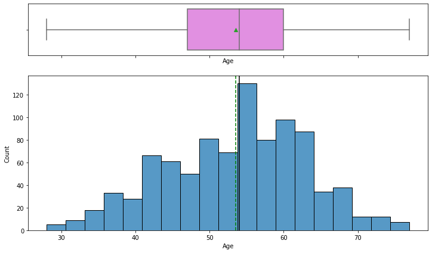

```python
# Observation on Age
histogram_boxplot(hd, 'Age')
```

- Age is fairly symmetrical, slightly left skewed.

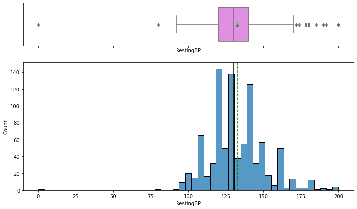

```python
# Observation on RestingBP
histogram_boxplot(hd, 'RestingBP')
```

- RestingBP is symmetrical with outliers on both the low and high ends.

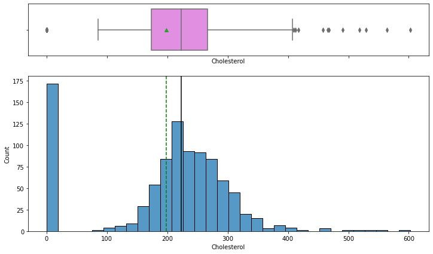

```python
# Observation on Cholesterol
histogram_boxplot(hd, 'Cholesterol')
```

- Cholesterol is normally distributed for the most part with outliers on both ends. Some of these values cannot occur so will have to be dealt with later.

```python
hd['Cholesterol'].describe()
```

```
count   918.000
mean    198.800
std     109.384
min       0.000
25%     173.250
50%     223.000
75%     267.000
max     603.000
Name: Cholesterol, dtype: float64
```

```python
hd.Cholesterol.replace({0: hd.Cholesterol.mean()}, inplace=True)
```

```python
hd['Cholesterol'].describe()
```

```
count   918.000
mean    236.047
std      56.241
min      85.000
25%     198.800
50%     223.000
75%     267.000
max     603.000
Name: Cholesterol, dtype: float64
```

```python
hd.describe().T
```

|  | count | mean | std | min | 25% | 50% | 75% | max |
| --- | --- | --- | --- | --- | --- | --- | --- | --- |
| Age | 918.000 | 53.511 | 9.433 | 28.000 | 47.000 | 54.000 | 60.000 | 77.000 |
| RestingBP | 918.000 | 132.397 | 18.514 | 0.000 | 120.000 | 130.000 | 140.000 | 200.000 |
| Cholesterol | 918.000 | 236.047 | 56.241 | 85.000 | 198.800 | 223.000 | 267.000 | 603.000 |
| MaxHR | 918.000 | 136.809 | 25.460 | 60.000 | 120.000 | 138.000 | 156.000 | 202.000 |
| Oldpeak | 918.000 | 0.887 | 1.067 | -2.600 | 0.000 | 0.600 | 1.500 | 6.200 |

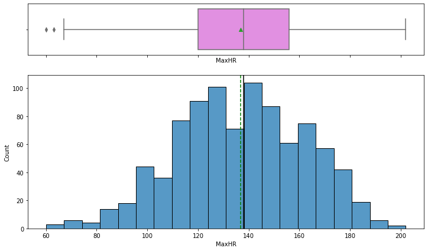

```python
# Observation on MaxHR
histogram_boxplot(hd, 'MaxHR')
```

- MaxHR is normally distributed with few outliers on the low end.

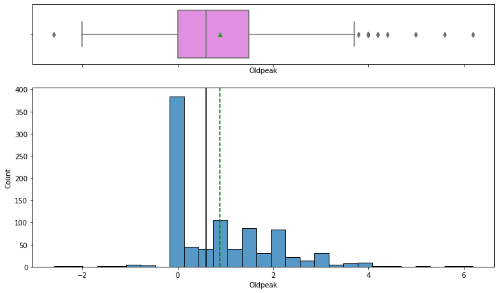

```python
# Observation on Oldpeak
histogram_boxplot(hd, 'Oldpeak')
```

- Oldpeak is right skewed with one outlier on the low end and many on the high end.

```python
# function to create labeled barplots


def labeled_barplot(data, feature, perc=False, n=None):
    """
    Barplot with percentage at the top

    data: dataframe
    feature: dataframe column
    perc: whether to display percentages instead of count (default is False)
    n: displays the top n category levels (default is None, i.e., display all levels)
    """

    total = len(data[feature])  # length of the column
    count = data[feature].nunique()
    if n is None:
        plt.figure(figsize=(count + 1, 5))
    else:
        plt.figure(figsize=(n + 1, 5))

    plt.xticks(rotation=90, fontsize=15)
    ax = sns.countplot(
        data=data,
        x=feature,
        palette="Paired",
        order=data[feature].value_counts().index[:n].sort_values(),
    )

    for p in ax.patches:
        if perc == True:
            label = "{:.1f}%".format(
                100 * p.get_height() / total
            )  # percentage of each class of the category
        else:
            label = p.get_height()  # count of each level of the category

        x = p.get_x() + p.get_width() / 2  # width of the plot
        y = p.get_height()  # height of the plot

        ax.annotate(
            label,
            (x, y),
            ha="center",
            va="center",
            size=12,
            xytext=(0, 5),
            textcoords="offset points",
        )  # annotate the percentage

    plt.show()  # show the plot
```

## Visualizing Categorical varibles in bar graphs.

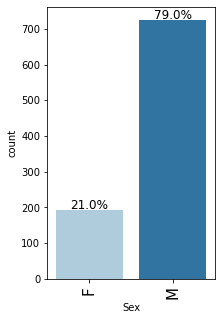

```python
labeled_barplot(hd, 'Sex', perc=True)
```

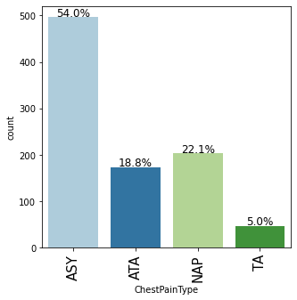

```python
labeled_barplot(hd, 'ChestPainType', perc=True)
```

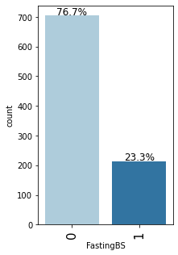

```python
labeled_barplot(hd, 'FastingBS', perc=True)
```

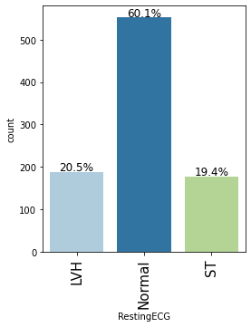

```python
labeled_barplot(hd, 'RestingECG', perc=True)
```

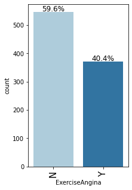

```python
labeled_barplot(hd, 'ExerciseAngina', perc=True)
```

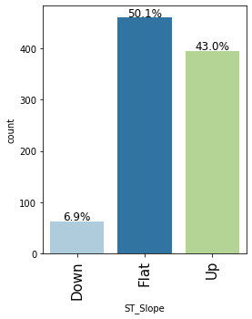

```python
labeled_barplot(hd, 'ST_Slope', perc=True)
```

## Bivariate Analysis

```python
# Changing HeartDisease to a integer for the heat map
hd['HeartDisease'] = hd.HeartDisease.astype(int)
```

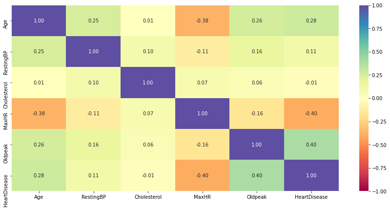

```python
plt.figure(figsize=(15, 7))
sns.heatmap(hd.corr(), annot=True, vmin=-1, vmax=1, fmt=".2f", cmap="Spectral")
plt.show()
```

- Heat Disease and Oldpeak have the most posiive of all correlations as they relate.
- Hear Disease and Max HR have the most negative of all correlations as they relate.

```python
# Changing HeartDisease back to a categorical variable
hd['HeartDisease'] = hd.HeartDisease.astype('category')
```

```python
def stacked_barplot(data, predictor, target):
    """
    Print the category counts and plot a stacked bar chart

    data: dataframe
    predictor: independent variable
    target: target variable
    """
    count = data[predictor].nunique()
    sorter = data[target].value_counts().index[-1]
    tab1 = pd.crosstab(data[predictor], data[target], margins=True).sort_values(
        by=sorter, ascending=False
    )
    print(tab1)
    print("-" * 120)
    tab = pd.crosstab(data[predictor], data[target], normalize="index").sort_values(
        by=sorter, ascending=False
    )
    tab.plot(kind="bar", stacked=True, figsize=(count + 5, 5))
    plt.legend(
        loc="lower left", frameon=False,
    )
    plt.legend(loc="upper left", bbox_to_anchor=(1, 1))
    plt.show()
```

```
HeartDisease    0    1  All
Sex
All           410  508  918
M             267  458  725
F             143   50  193
------------------------------------------------------------------------------------------------------------------------
```

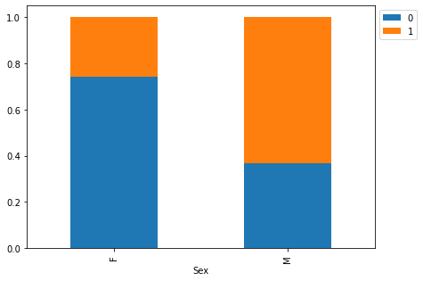

```python
stacked_barplot(hd, 'Sex', 'HeartDisease')
```

- Most men in the dataset have hear disease.

```
HeartDisease     0    1  All
ChestPainType
All            410  508  918
ATA            149   24  173
NAP            131   72  203
ASY            104  392  496
TA              26   20   46
------------------------------------------------------------------------------------------------------------------------
```

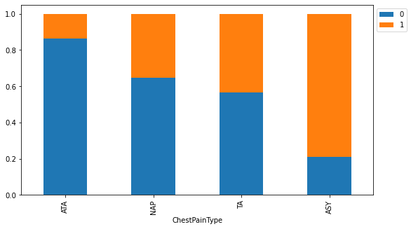

```python
stacked_barplot(hd, 'ChestPainType', 'HeartDisease')
```

- Patients with ASY angina have heart disease at the higest rate compared to other cases of angina.

```
HeartDisease    0    1  All
FastingBS
All           410  508  918
0             366  338  704
1              44  170  214
------------------------------------------------------------------------------------------------------------------------
```

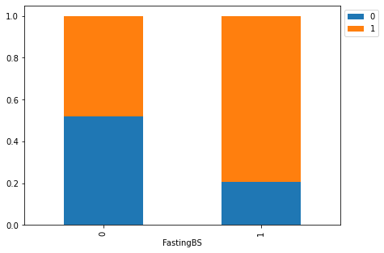

```python
stacked_barplot(hd, 'FastingBS', 'HeartDisease')
```

- Patients with higher Fasting Blood Sugar have heart disease at a higer rate than those with lower.

```
HeartDisease    0    1  All
RestingECG
All           410  508  918
Normal        267  285  552
LVH            82  106  188
ST             61  117  178
------------------------------------------------------------------------------------------------------------------------
```

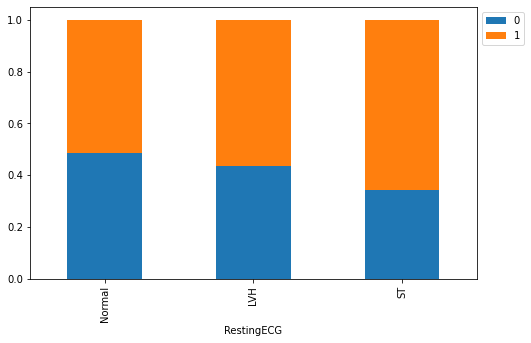

```python
stacked_barplot(hd, 'RestingECG', 'HeartDisease')
```

- Patients with LVH and ST ResteingECG have heart disease at a higher rate than those at the Normal level; though there isn't too much varince between the three.

```
HeartDisease    0    1  All
ST_Slope
All           410  508  918
Up            317   78  395
Flat           79  381  460
Down           14   49   63
------------------------------------------------------------------------------------------------------------------------
```

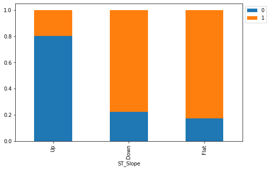

```python
stacked_barplot(hd, 'ST_Slope', 'HeartDisease')
```

- Patients with a ST Slope that is Down or Flat have heart disease at much higher rates than those with one that's up.

```python
# Looking at averages of postive and negative cases between men and women.
hd.groupby(["Sex","HeartDisease"], as_index=False)["Age"].mean()
```

|  | Sex | HeartDisease | Age |
| --- | --- | --- | --- |
| 0 | F | 0 | 51.203 |
| 1 | F | 1 | 56.180 |
| 2 | M | 0 | 50.202 |
| 3 | M | 1 | 55.869 |

## We see above there is no significant age gap between postive and negative cases of heart disease between men and women.

```python
# Looking at averages of postive and negative cases between men and women.
hd.groupby(["Sex","HeartDisease"], as_index=False)["MaxHR"].mean()
```

|  | Sex | HeartDisease | MaxHR |
| --- | --- | --- | --- |
| 0 | F | 0 | 149.049 |
| 1 | F | 1 | 137.820 |
| 2 | M | 0 | 147.670 |
| 3 | M | 1 | 126.546 |

## According to the table men and women with higher heart rates are less likely to have heart disease.

```python
# Looking at averages of postive and negative cases between men and women.
hd.groupby(["Sex","HeartDisease"], as_index=False)["Cholesterol"].mean()
```

|  | Sex | HeartDisease | Cholesterol |
| --- | --- | --- | --- |
| 0 | F | 0 | 248.831 |
| 1 | F | 1 | 263.100 |
| 2 | M | 0 | 230.386 |
| 3 | M | 1 | 232.403 |

## Cholesterol does not seem to be a significant indicator of heart disease.

```python
### function to plot distributions wrt target


def distribution_plot_wrt_target(data, predictor, target):

    fig, axs = plt.subplots(2, 2, figsize=(12, 10))

    target_uniq = data[target].unique()

    axs[0, 0].set_title("Distribution of target for target=" + str(target_uniq[0]))
    sns.histplot(
        data=data[data[target] == target_uniq[0]],
        x=predictor,
        kde=True,
        ax=axs[0, 0],
        color="teal",
        stat="density",
    )

    axs[0, 1].set_title("Distribution of target for target=" + str(target_uniq[1]))
    sns.histplot(
        data=data[data[target] == target_uniq[1]],
        x=predictor,
        kde=True,
        ax=axs[0, 1],
        color="orange",
        stat="density",
    )

    axs[1, 0].set_title("Boxplot w.r.t target")
    sns.boxplot(data=data, x=target, y=predictor, ax=axs[1, 0], palette="gist_rainbow")

    axs[1, 1].set_title("Boxplot (without outliers) w.r.t target")
    sns.boxplot(
        data=data,
        x=target,
        y=predictor,
        ax=axs[1, 1],
        showfliers=False,
        palette="gist_rainbow",
    )

    plt.tight_layout()
    plt.show()
```

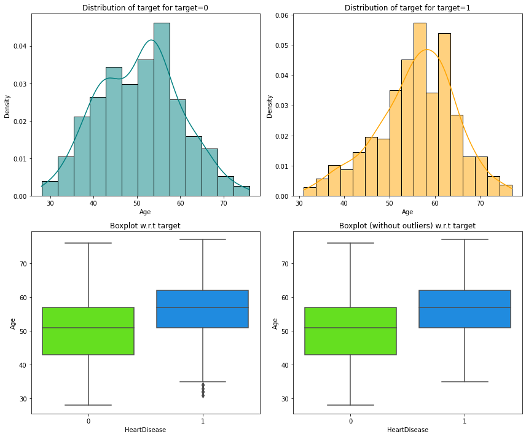

```python
distribution_plot_wrt_target(hd, 'Age', 'HeartDisease')
```

## Looking above we see that older patients are slightly at a higher risk for heart disease.

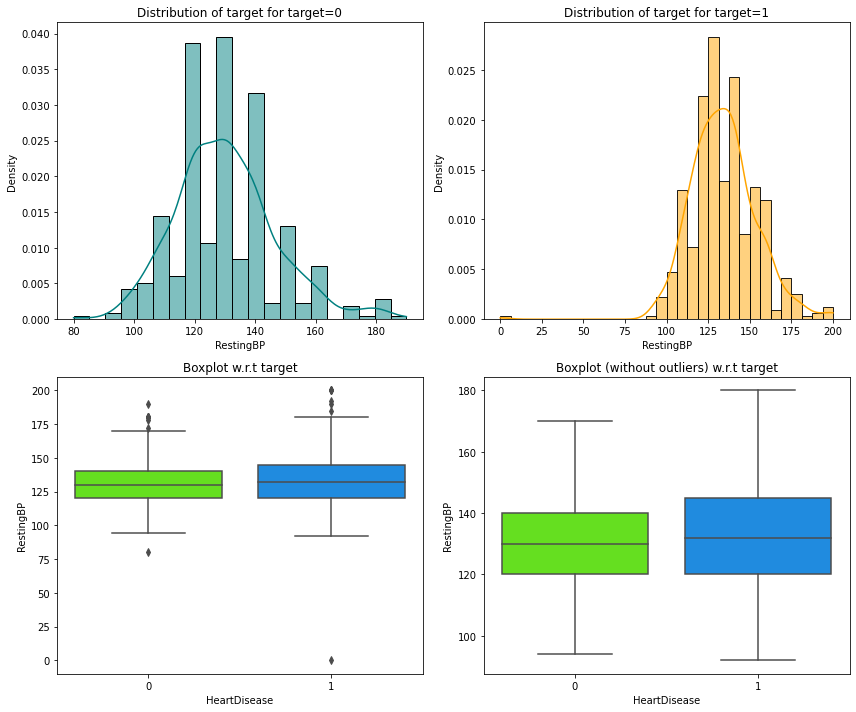

```python
distribution_plot_wrt_target(hd, 'RestingBP', 'HeartDisease')
```

## Above we see no significant differnce for RestingBP in relation to heart disease.

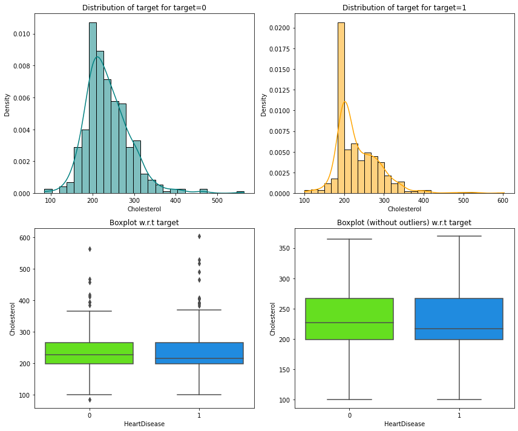

```python
distribution_plot_wrt_target(hd, 'Cholesterol', 'HeartDisease')
```

## Above we see no significant differnce for Cholesterol in relation to heart disease.

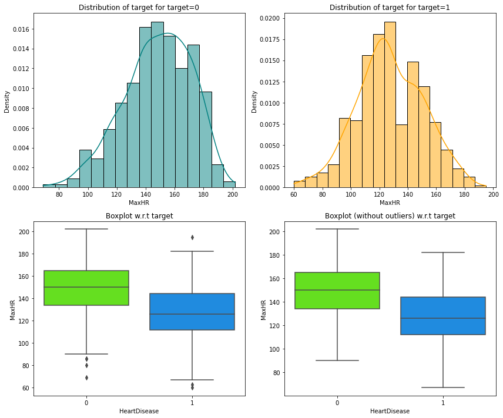

```python
distribution_plot_wrt_target(hd, 'MaxHR', 'HeartDisease')
```

## Above we see that those with a slightly higher MaxHR are not as much at risk of getting heart disease.

## Let's look at outliers in every numerical column

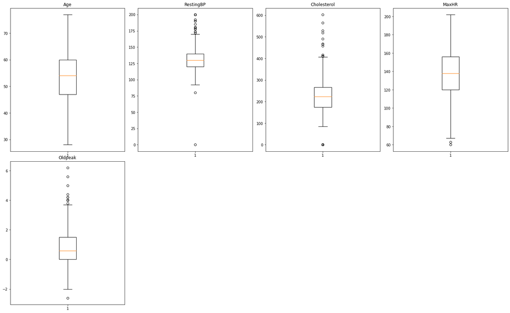

```python
# let's plot the boxplots of all columns to check for outliers
numeric_columns = ['Age', 'RestingBP', 'Cholesterol', 'MaxHR', 'Oldpeak']

plt.figure(figsize=(20, 30))

for i, variable in enumerate(numeric_columns):
    plt.subplot(5, 4, i + 1)
    plt.boxplot(df[variable], whis=1.5)
    plt.tight_layout()
    plt.title(variable)

plt.show()
```

- We have outliers in RestingBP, Cholesterol, MaxHR, and Oldpeak.
- We will treat these outliers as these might adversely affect the predictive power of linear model. However, in real life, these outliers may be due to non-linear pattern in the data or can be important information.
- Sometimes outliers in the independent variable can adversely impact the linear model. This can be checked by building the model with and without outliers and comparing the model performances.

## Outlier Treatment

```python
# Let's treat outliers by flooring and capping
def treat_outliers(hd, col):
    """
    treats outliers in a variable
    col: str, name of the numerical variable
    df: dataframe
    col: name of the column
    """
    Q1 = hd[col].quantile(0.25)  # 25th quantile
    Q3 = hd[col].quantile(0.75)  # 75th quantile
    IQR = Q3 - Q1
    Lower_Whisker = Q1 - 1.5 * IQR
    Upper_Whisker = Q3 + 1.5 * IQR

    # all the values smaller than Lower_Whisker will be assigned the value of Lower_Whisker
    # all the values greater than Upper_Whisker will be assigned the value of Upper_Whisker
    hd[col] = np.clip(hd[col], Lower_Whisker, Upper_Whisker)

    return df


def treat_outliers_all(hd, col_list):
    """
    treat outlier in all numerical variables
    col_list: list of numerical variables
    df: data frame
    """
    for c in col_list:
        hd = treat_outliers(df, c)

    return hd
```

### Treating the outliers

```python
numerical_col = hd.select_dtypes(include=np.number).columns.tolist()
hd = treat_outliers_all(hd, numerical_col)
```

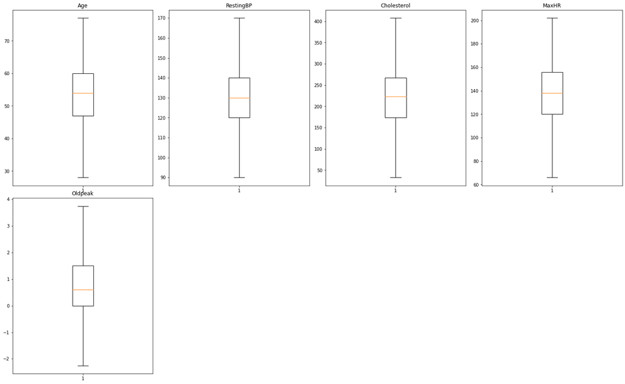

```python
# let's look at box plot to see if outliers have been treated or not
plt.figure(figsize=(20, 30))

for i, variable in enumerate(numeric_columns):
    plt.subplot(5, 4, i + 1)
    plt.boxplot(df[variable], whis=1.5)
    plt.tight_layout()
    plt.title(variable)

plt.show()
```

## Outliers have been treated.

```python
hd.head(10)
```

|  | Age | Sex | ChestPainType | RestingBP | Cholesterol | FastingBS | RestingECG | MaxHR | ExerciseAngina | Oldpeak | ST_Slope | HeartDisease |
| --- | --- | --- | --- | --- | --- | --- | --- | --- | --- | --- | --- | --- |
| 0 | 40 | M | ATA | 140 | 289.000 | 0 | Normal | 172 | N | 0.000 | Up | 0 |
| 1 | 49 | F | NAP | 160 | 180.000 | 0 | Normal | 156 | N | 1.000 | Flat | 1 |
| 2 | 37 | M | ATA | 130 | 283.000 | 0 | ST | 98 | N | 0.000 | Up | 0 |
| 3 | 48 | F | ASY | 138 | 214.000 | 0 | Normal | 108 | Y | 1.500 | Flat | 1 |
| 4 | 54 | M | NAP | 150 | 195.000 | 0 | Normal | 122 | N | 0.000 | Up | 0 |
| 5 | 39 | M | NAP | 120 | 339.000 | 0 | Normal | 170 | N | 0.000 | Up | 0 |
| 6 | 45 | F | ATA | 130 | 237.000 | 0 | Normal | 170 | N | 0.000 | Up | 0 |
| 7 | 54 | M | ATA | 110 | 208.000 | 0 | Normal | 142 | N | 0.000 | Up | 0 |
| 8 | 37 | M | ASY | 140 | 207.000 | 0 | Normal | 130 | Y | 1.500 | Flat | 1 |
| 9 | 48 | F | ATA | 120 | 284.000 | 0 | Normal | 120 | N | 0.000 | Up | 0 |

### Model evaluation criterion

### Model can make wrong predictions as:

1. Predicting a patient is not going to get Heart Disease but in reality the patient does. - Loss of resources
2. Predicting a patient is going to get Heart Disease but in reality the patient does not. - Loss of opportunity

### Which Loss is greater ?

- Loss of resources will be the greater loss as the patient will not get needed treatment.

### How to reduce this loss i.e need to reduce False Negatives ?

- Company would want to reduce false negatives, this can be done by maximizing the Recall. Greater the recall lesser the chances of false negatives.

#### First, let's create functions to calculate different metrics and confusion matrix so that we don't have to use the same code repeatedly for each model.

- The model_performance_classification_statsmodels function will be used to check the model performance of models.
- The confusion_matrix_statsmodels function will be used to plot confusion matrix.

```python
# defining a function to compute different metrics to check performance of a classification model built using statsmodels
def model_performance_classification_statsmodels(
    model, predictors, target, threshold=0.5
):
    """
    Function to compute different metrics to check classification model performance

    model: classifier
    predictors: independent variables
    target: dependent variable
    threshold: threshold for classifying the observation as class 1
    """

    # checking which probabilities are greater than threshold
    pred_temp = model.predict(predictors) > threshold
    # rounding off the above values to get classes
    pred = np.round(pred_temp)

    acc = accuracy_score(target, pred)  # to compute Accuracy
    recall = recall_score(target, pred)  # to compute Recall
    precision = precision_score(target, pred)  # to compute Precision
    f1 = f1_score(target, pred)  # to compute F1-score

    # creating a dataframe of metrics
    df_perf = pd.DataFrame(
        {"Accuracy": acc, "Recall": recall, "Precision": precision, "F1": f1,},
        index=[0],
    )

    return df_perf
```

```python
# defining a function to plot the confusion_matrix of a classification model


def confusion_matrix_statsmodels(model, predictors, target, threshold=0.5):
    """
    To plot the confusion_matrix with percentages

    model: classifier
    predictors: independent variables
    target: dependent variable
    threshold: threshold for classifying the observation as class 1
    """
    y_pred = model.predict(predictors) > threshold
    cm = confusion_matrix(target, y_pred)
    labels = np.asarray(
        [
            ["{0:0.0f}".format(item) + "\n{0:.2%}".format(item / cm.flatten().sum())]
            for item in cm.flatten()
        ]
    ).reshape(2, 2)

    plt.figure(figsize=(6, 4))
    sns.heatmap(cm, annot=labels, fmt="")
    plt.ylabel("True label")
    plt.xlabel("Predicted label")
```

# Data Preparation Logistic Regression (with statsmodels library)

```python
X = hd.drop("HeartDisease", axis=1)
Y = hd["HeartDisease"]

# creating dummy variables
X = pd.get_dummies(X, drop_first=True)

# adding constant
X = sm.add_constant(X)

# splitting in training and test set
X_train, X_test, y_train, y_test = train_test_split(X, Y, test_size=0.3, random_state=1)
```

```python
print("Shape of Training set : ", X_train.shape)
print("Shape of test set : ", X_test.shape)
print("Percentage of classes in training set:")
print(y_train.value_counts(normalize=True))
print("Percentage of classes in test set:")
print(y_test.value_counts(normalize=True))
```

```
Shape of Training set :  (642, 16)
Shape of test set :  (276, 16)
Percentage of classes in training set:
1   0.531
0   0.469
Name: HeartDisease, dtype: float64
Percentage of classes in test set:
1   0.605
0   0.395
Name: HeartDisease, dtype: float64
```

```python
logit = sm.Logit(y_train, X_train.astype(float))
lg = logit.fit(
    disp=False
)  # setting disp=False will remove the information on number of iterations

print(lg.summary())
```

```
                           Logit Regression Results
==============================================================================
Dep. Variable:           HeartDisease   No. Observations:                  642
Model:                          Logit   Df Residuals:                      626
Method:                           MLE   Df Model:                           15
Date:                Tue, 08 Mar 2022   Pseudo R-squ.:                  0.5284
Time:                        22:02:12   Log-Likelihood:                -209.28
converged:                       True   LL-Null:                       -443.75
Covariance Type:            nonrobust   LLR p-value:                 2.058e-90
=====================================================================================
                        coef    std err          z      P>|z|      [0.025      0.975]
-------------------------------------------------------------------------------------
const                -2.1176      1.721     -1.230      0.219      -5.491       1.255
Age                   0.0185      0.016      1.145      0.252      -0.013       0.050
RestingBP             0.0094      0.008      1.150      0.250      -0.007       0.025
Cholesterol          -0.0055      0.002     -3.609      0.000      -0.008      -0.003
FastingBS             1.0620      0.328      3.237      0.001       0.419       1.705
MaxHR                -0.0023      0.006     -0.362      0.717      -0.014       0.010
Oldpeak               0.4359      0.141      3.096      0.002       0.160       0.712
Sex_M                 1.5323      0.343      4.466      0.000       0.860       2.205
ChestPainType_ATA    -2.0184      0.416     -4.849      0.000      -2.834      -1.203
ChestPainType_NAP    -1.9138      0.317     -6.043      0.000      -2.534      -1.293
ChestPainType_TA     -1.6108      0.528     -3.053      0.002      -2.645      -0.577
RestingECG_Normal    -0.0792      0.326     -0.243      0.808      -0.719       0.560
RestingECG_ST        -0.3289      0.414     -0.795      0.427      -1.140       0.482
ExerciseAngina_Y      0.8733      0.284      3.072      0.002       0.316       1.431
ST_Slope_Flat         1.4135      0.527      2.680      0.007       0.380       2.447
ST_Slope_Up          -0.9200      0.556     -1.655      0.098      -2.010       0.170
=====================================================================================
```

```python
print("Training performance:")
model_performance_classification_statsmodels(lg, X_train, y_train)
```

```
Training performance:
```

|  | Accuracy | Recall | Precision | F1 |
| --- | --- | --- | --- | --- |
| 0 | 0.871 | 0.903 | 0.860 | 0.881 |

**Observations**

- Negative values of the coefficient shows that probability of patient getting Heart Disease decreases with the increase of corresponding attribute value.
- Positive values of the coefficient show that that probability of a patient getting Heart Disease increases with the increase of corresponding attribute value.
- p-value of a variable indicates if the variable is significant or not. If we consider the significance level to be 0.05 (5%), then any variable with a p-value less than 0.05 would be considered significant.
- But these variables might contain multicollinearity, which will affect the p-values.
- We will have to remove multicollinearity from the data to get reliable coefficients and p-values.
- There are different ways of detecting (or testing) multi-collinearity, one such way is the Variation Inflation Factor.

### Additional Information on VIF

- **Variance Inflation factor**: Variance inflation factors measure the inflation in the variances of the regression coefficients estimates due to collinearity that exist among the predictors. It is a measure of how much the variance of the estimated regression coefficient βk is "inflated" by the existence of correlation among the predictor variables in the model.
- General Rule of thumb: If VIF is 1 then there is no correlation among the kth predictor and the remaining predictor variables, and hence the variance of β̂k is not inflated at all. Whereas if VIF exceeds 5, we say there is moderate VIF and if it is 10 or exceeding 10, it shows signs of high multi-collinearity. But the purpose of the analysis should dictate which threshold to use.

## Multicollinearity

```python
vif_series = pd.Series(
    [variance_inflation_factor(X_train.values, i) for i in range(X_train.shape[1])],
    index=X_train.columns,
    dtype=float,
)
print("Series before feature selection: \n\n{}\n".format(vif_series))
```

```
Series before feature selection:

const               200.343
Age                   1.386
RestingBP             1.130
Cholesterol           1.309
FastingBS             1.170
MaxHR                 1.577
Oldpeak               1.460
Sex_M                 1.113
ChestPainType_ATA     1.484
ChestPainType_NAP     1.231
ChestPainType_TA      1.103
RestingECG_Normal     1.773
RestingECG_ST         1.774
ExerciseAngina_Y      1.552
ST_Slope_Flat         5.237
ST_Slope_Up           6.179
dtype: float64
```

- ST_Slope_Flat and ST_Slope_UP are highly correlated, so we will drop one of them depending on which has less effect on making predictions.

### Dropping ST_Slope_Flat

```python
X_train1 = X_train.drop("ST_Slope_Flat", axis=1)
vif_series2 = pd.Series(
    [variance_inflation_factor(X_train1.values, i) for i in range(X_train1.shape[1])],
    index=X_train1.columns,
)
print("Series before feature selection: \n\n{}\n".format(vif_series2))
```

```
Series before feature selection:

const               186.049
Age                   1.386
RestingBP             1.124
Cholesterol           1.297
FastingBS             1.170
MaxHR                 1.576
Oldpeak               1.410
Sex_M                 1.113
ChestPainType_ATA     1.483
ChestPainType_NAP     1.230
ChestPainType_TA      1.103
RestingECG_Normal     1.771
RestingECG_ST         1.770
ExerciseAngina_Y      1.552
ST_Slope_Up           1.669
dtype: float64
```

- Removal of ST_Slope_Flat column results in removal of multicollinearity from the data.

```python
logit1 = sm.Logit(y_train, X_train1.astype(float))
lg1 = logit1.fit(disp=False)

print("Training performance:")
model_performance_classification_statsmodels(lg1, X_train1, y_train)
```

```
Training performance:
```

|  | Accuracy | Recall | Precision | F1 |
| --- | --- | --- | --- | --- |
| 0 | 0.864 | 0.897 | 0.855 | 0.876 |

- No significant change in the model performance.

### Dropping ST_Slope_Up

```python
X_train2 = X_train.drop("ST_Slope_Up", axis=1)
vif_series3 = pd.Series(
    [variance_inflation_factor(X_train2.values, i) for i in range(X_train2.shape[1])],
    index=X_train2.columns,
)
print("Series before feature selection: \n\n{}\n".format(vif_series3))
```

```
Series before feature selection:

const               187.160
Age                   1.384
RestingBP             1.127
Cholesterol           1.302
FastingBS             1.167
MaxHR                 1.567
Oldpeak               1.331
Sex_M                 1.113
ChestPainType_ATA     1.475
ChestPainType_NAP     1.231
ChestPainType_TA      1.103
RestingECG_Normal     1.771
RestingECG_ST         1.769
ExerciseAngina_Y      1.521
ST_Slope_Flat         1.415
dtype: float64
```

- Removal of ST_Slope_Up column results in removal of multicollinearity from the data.

```python
logit2 = sm.Logit(y_train, X_train2.astype(float))
lg2 = logit2.fit(disp=False)

print("Training performance:")
model_performance_classification_statsmodels(lg2, X_train2, y_train)
```

```
Training performance:
```

|  | Accuracy | Recall | Precision | F1 |
| --- | --- | --- | --- | --- |
| 0 | 0.864 | 0.894 | 0.857 | 0.875 |

- No significant change in the model performance.

**Observations**

- The performance of lg1 and lg2 is the same so we can choose either of these models.
- Dropping ST_Slope_Flat or ST_Slope_Up removes the multicollinearity from the data.
- Let's proceed with lg2 i.e. dropping the ST_Slope_Up variable and keeping the ST_Slope_Flat variable

```python
# Let's Look at summary of lg2 model.
print(lg2.summary())
```

```
                           Logit Regression Results
==============================================================================
Dep. Variable:           HeartDisease   No. Observations:                  642
Model:                          Logit   Df Residuals:                      627
Method:                           MLE   Df Model:                           14
Date:                Tue, 08 Mar 2022   Pseudo R-squ.:                  0.5252
Time:                        22:02:13   Log-Likelihood:                -210.69
converged:                       True   LL-Null:                       -443.75
Covariance Type:            nonrobust   LLR p-value:                 1.388e-90
=====================================================================================
                        coef    std err          z      P>|z|      [0.025      0.975]
-------------------------------------------------------------------------------------
const                -2.5868      1.670     -1.549      0.121      -5.860       0.686
Age                   0.0180      0.016      1.119      0.263      -0.014       0.049
RestingBP             0.0086      0.008      1.066      0.286      -0.007       0.024
Cholesterol          -0.0056      0.002     -3.682      0.000      -0.009      -0.003
FastingBS             1.0958      0.327      3.355      0.001       0.456       1.736
MaxHR                -0.0037      0.006     -0.599      0.549      -0.016       0.008
Oldpeak               0.5148      0.132      3.885      0.000       0.255       0.774
Sex_M                 1.5003      0.341      4.399      0.000       0.832       2.169
ChestPainType_ATA    -2.0392      0.414     -4.922      0.000      -2.851      -1.227
ChestPainType_NAP    -1.8823      0.314     -5.992      0.000      -2.498      -1.267
ChestPainType_TA     -1.5810      0.527     -3.002      0.003      -2.613      -0.549
RestingECG_Normal    -0.1117      0.324     -0.345      0.730      -0.747       0.524
RestingECG_ST        -0.3484      0.411     -0.849      0.396      -1.153       0.456
ExerciseAngina_Y      0.9375      0.281      3.342      0.001       0.388       1.487
ST_Slope_Flat         2.1507      0.273      7.864      0.000       1.615       2.687
=====================================================================================
```

- Observe that the p-value of Age, RestingBP, MaxHR, RestingECG_Normal, and RestingECG_ST is greater than 0.05, they are insignificant.
- Let's drop the insignificant variables observe how our model changes.

```python
# Dropping Age
X_train3 = X_train2.drop(
    ['Age'],
    axis=1,
)
logit3 = sm.Logit(y_train, X_train3.astype(float))
lg3 = logit3.fit(disp=False)

print(lg3.summary())
```

```
                           Logit Regression Results
==============================================================================
Dep. Variable:           HeartDisease   No. Observations:                  642
Model:                          Logit   Df Residuals:                      628
Method:                           MLE   Df Model:                           13
Date:                Tue, 08 Mar 2022   Pseudo R-squ.:                  0.5238
Time:                        22:02:13   Log-Likelihood:                -211.32
converged:                       True   LL-Null:                       -443.75
Covariance Type:            nonrobust   LLR p-value:                 4.193e-91
=====================================================================================
                        coef    std err          z      P>|z|      [0.025      0.975]
-------------------------------------------------------------------------------------
const                -1.5608      1.386     -1.126      0.260      -4.278       1.156
RestingBP             0.0106      0.008      1.346      0.178      -0.005       0.026
Cholesterol          -0.0057      0.002     -3.793      0.000      -0.009      -0.003
FastingBS             1.1181      0.326      3.434      0.001       0.480       1.756
MaxHR                -0.0057      0.006     -0.971      0.331      -0.017       0.006
Oldpeak               0.5467      0.130      4.199      0.000       0.292       0.802
Sex_M                 1.4986      0.341      4.389      0.000       0.829       2.168
ChestPainType_ATA    -2.0367      0.413     -4.933      0.000      -2.846      -1.227
ChestPainType_NAP    -1.8694      0.313     -5.976      0.000      -2.483      -1.256
ChestPainType_TA     -1.5265      0.521     -2.930      0.003      -2.548      -0.505
RestingECG_Normal    -0.1924      0.315     -0.610      0.542      -0.810       0.425
RestingECG_ST        -0.3915      0.408     -0.959      0.338      -1.192       0.409
ExerciseAngina_Y      0.9365      0.280      3.340      0.001       0.387       1.486
ST_Slope_Flat         2.1626      0.273      7.925      0.000       1.628       2.697
=====================================================================================
```

```python
# Dropping RestingBP
X_train4 = X_train3.drop(["RestingBP"], axis=1)
logit4 = sm.Logit(y_train, X_train4.astype(float))
lg4 = logit4.fit(disp=False)

print(lg4.summary())
```

```
                           Logit Regression Results
==============================================================================
Dep. Variable:           HeartDisease   No. Observations:                  642
Model:                          Logit   Df Residuals:                      629
Method:                           MLE   Df Model:                           12
Date:                Tue, 08 Mar 2022   Pseudo R-squ.:                  0.5217
Time:                        22:02:13   Log-Likelihood:                -212.24
converged:                       True   LL-Null:                       -443.75
Covariance Type:            nonrobust   LLR p-value:                 1.609e-91
=====================================================================================
                        coef    std err          z      P>|z|      [0.025      0.975]
-------------------------------------------------------------------------------------
const                -0.2343      0.971     -0.241      0.809      -2.137       1.669
Cholesterol          -0.0053      0.001     -3.637      0.000      -0.008      -0.002
FastingBS             1.1464      0.325      3.528      0.000       0.510       1.783
MaxHR                -0.0061      0.006     -1.050      0.294      -0.017       0.005
Oldpeak               0.5633      0.129      4.371      0.000       0.311       0.816
Sex_M                 1.4695      0.338      4.342      0.000       0.806       2.133
ChestPainType_ATA    -1.9931      0.410     -4.861      0.000      -2.797      -1.189
ChestPainType_NAP    -1.8467      0.312     -5.915      0.000      -2.459      -1.235
ChestPainType_TA     -1.4814      0.521     -2.844      0.004      -2.502      -0.461
RestingECG_Normal    -0.1838      0.314     -0.586      0.558      -0.798       0.431
RestingECG_ST        -0.3352      0.404     -0.830      0.407      -1.127       0.456
ExerciseAngina_Y      0.9585      0.280      3.426      0.001       0.410       1.507
ST_Slope_Flat         2.1747      0.272      8.000      0.000       1.642       2.707
=====================================================================================
```

```python
# Dropping MaxHR
X_train5 = X_train4.drop(["MaxHR"], axis=1)
logit5 = sm.Logit(y_train, X_train5.astype(float))
lg5 = logit5.fit(disp=False)

print(lg5.summary())
```

```
                           Logit Regression Results
==============================================================================
Dep. Variable:           HeartDisease   No. Observations:                  642
Model:                          Logit   Df Residuals:                      630
Method:                           MLE   Df Model:                           11
Date:                Tue, 08 Mar 2022   Pseudo R-squ.:                  0.5205
Time:                        22:02:14   Log-Likelihood:                -212.79
converged:                       True   LL-Null:                       -443.75
Covariance Type:            nonrobust   LLR p-value:                 4.155e-92
=====================================================================================
                        coef    std err          z      P>|z|      [0.025      0.975]
-------------------------------------------------------------------------------------
const                -1.0800      0.546     -1.979      0.048      -2.150      -0.010
Cholesterol          -0.0057      0.001     -4.034      0.000      -0.008      -0.003
FastingBS             1.1256      0.325      3.467      0.001       0.489       1.762
Oldpeak               0.5593      0.128      4.357      0.000       0.308       0.811
Sex_M                 1.5028      0.338      4.453      0.000       0.841       2.164
ChestPainType_ATA    -2.0306      0.409     -4.967      0.000      -2.832      -1.229
ChestPainType_NAP    -1.8881      0.309     -6.103      0.000      -2.494      -1.282
ChestPainType_TA     -1.5145      0.527     -2.876      0.004      -2.547      -0.482
RestingECG_Normal    -0.1571      0.311     -0.505      0.614      -0.767       0.453
RestingECG_ST        -0.2662      0.398     -0.668      0.504      -1.047       0.514
ExerciseAngina_Y      1.0246      0.273      3.757      0.000       0.490       1.559
ST_Slope_Flat         2.2346      0.266      8.390      0.000       1.713       2.757
=====================================================================================
```

```python
# Dropping RestingECG_Normal
X_train6 = X_train5.drop(["RestingECG_Normal"], axis=1)
logit6 = sm.Logit(y_train, X_train6.astype(float))
lg6 = logit6.fit(disp=False)

print(lg6.summary())
```

```
                           Logit Regression Results
==============================================================================
Dep. Variable:           HeartDisease   No. Observations:                  642
Model:                          Logit   Df Residuals:                      631
Method:                           MLE   Df Model:                           10
Date:                Tue, 08 Mar 2022   Pseudo R-squ.:                  0.5202
Time:                        22:02:14   Log-Likelihood:                -212.92
converged:                       True   LL-Null:                       -443.75
Covariance Type:            nonrobust   LLR p-value:                 6.745e-93
=====================================================================================
                        coef    std err          z      P>|z|      [0.025      0.975]
-------------------------------------------------------------------------------------
const                -1.2053      0.487     -2.474      0.013      -2.160      -0.250
Cholesterol          -0.0056      0.001     -4.006      0.000      -0.008      -0.003
FastingBS             1.1283      0.325      3.475      0.001       0.492       1.765
Oldpeak               0.5648      0.128      4.419      0.000       0.314       0.815
Sex_M                 1.4960      0.337      4.436      0.000       0.835       2.157
ChestPainType_ATA    -2.0493      0.407     -5.035      0.000      -2.847      -1.251
ChestPainType_NAP    -1.8868      0.309     -6.101      0.000      -2.493      -1.281
ChestPainType_TA     -1.5026      0.524     -2.865      0.004      -2.531      -0.475
RestingECG_ST        -0.1488      0.322     -0.461      0.644      -0.781       0.483
ExerciseAngina_Y      1.0147      0.272      3.731      0.000       0.482       1.548
ST_Slope_Flat         2.2274      0.266      8.383      0.000       1.707       2.748
=====================================================================================
```

```python
# Dropping RestingECG_ST
X_train7 = X_train6.drop(["RestingECG_ST"], axis=1)
logit7 = sm.Logit(y_train, X_train7.astype(float))
lg7 = logit7.fit(disp=False)

print(lg7.summary())
```

```
                           Logit Regression Results
==============================================================================
Dep. Variable:           HeartDisease   No. Observations:                  642
Model:                          Logit   Df Residuals:                      632
Method:                           MLE   Df Model:                            9
Date:                Tue, 08 Mar 2022   Pseudo R-squ.:                  0.5200
Time:                        22:02:15   Log-Likelihood:                -213.02
converged:                       True   LL-Null:                       -443.75
Covariance Type:            nonrobust   LLR p-value:                 1.015e-93
=====================================================================================
                        coef    std err          z      P>|z|      [0.025      0.975]
-------------------------------------------------------------------------------------
const                -1.2368      0.482     -2.567      0.010      -2.181      -0.292
Cholesterol          -0.0055      0.001     -3.987      0.000      -0.008      -0.003
FastingBS             1.1108      0.322      3.446      0.001       0.479       1.742
Oldpeak               0.5666      0.128      4.437      0.000       0.316       0.817
Sex_M                 1.4837      0.336      4.422      0.000       0.826       2.141
ChestPainType_ATA    -2.0534      0.408     -5.028      0.000      -2.854      -1.253
ChestPainType_NAP    -1.8793      0.309     -6.087      0.000      -2.484      -1.274
ChestPainType_TA     -1.5076      0.523     -2.884      0.004      -2.532      -0.483
ExerciseAngina_Y      1.0023      0.270      3.707      0.000       0.472       1.532
ST_Slope_Flat         2.2259      0.266      8.384      0.000       1.706       2.746
=====================================================================================
```

- All the variables left a significant (P-value<0.5).
- So we can say that lg7 is the best model for making any inference.

## Coefficient interpretations

- Coefficients of FastingBS, Oldpeak, ExerciseAngina_Y, and ST_Slop_Flat are positive an increase in these will lead to an increase in chances of a patient getting Heart Disease.
- Coefficients of Cholesterol, ChestPainType_ATA, ChestPainType_NAP, and ChestPainType_TA are negative an increase in these will lead to a decrease in chances of a patient getting Heart Disease.

**Checking model performance on the training set**

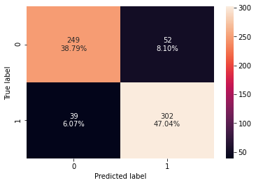

```python
# creating confusion matrix
confusion_matrix_statsmodels(lg7, X_train7, y_train)
```

```python
log_reg_model_train_perf = model_performance_classification_statsmodels(
    lg7, X_train7, y_train
)

print("Training performance:")
log_reg_model_train_perf
```

```
Training performance:
```

|  | Accuracy | Recall | Precision | F1 |
| --- | --- | --- | --- | --- |
| 0 | 0.858 | 0.886 | 0.853 | 0.869 |

### ROC-AUC

- ROC-AUC on training set

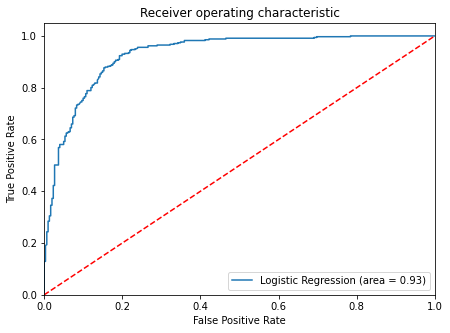

```python
logit_roc_auc_train = roc_auc_score(y_train, lg7.predict(X_train7))
fpr, tpr, thresholds = roc_curve(y_train, lg7.predict(X_train7))
plt.figure(figsize=(7, 5))
plt.plot(fpr, tpr, label="Logistic Regression (area = %0.2f)" % logit_roc_auc_train)
plt.plot([0, 1], [0, 1], "r--")
plt.xlim([0.0, 1.0])
plt.ylim([0.0, 1.05])
plt.xlabel("False Positive Rate")
plt.ylabel("True Positive Rate")
plt.title("Receiver operating characteristic")
plt.legend(loc="lower right")
plt.show()
```

- Logistic Regression model is giving a good performance on training and test set.
- ROC-AUC score of 0.93 on training is quite good.

## Optimal threshold using AUC-ROC curve

```python
# Optimal threshold as per AUC-ROC curve
# The optimal cut off would be where tpr is high and fpr is low
fpr, tpr, thresholds = roc_curve(y_train, lg7.predict(X_train7))

optimal_idx = np.argmax(tpr - fpr)
optimal_threshold_auc_roc = thresholds[optimal_idx]
print(optimal_threshold_auc_roc)
```

```
0.4116979571949174
```

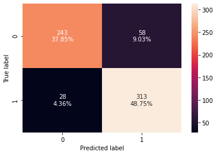

```python
# creating confusion matrix
confusion_matrix_statsmodels(
    lg5, X_train5, y_train, threshold=optimal_threshold_auc_roc
)
```

```python
# checking model performance for this model
log_reg_model_train_perf_threshold_auc_roc = model_performance_classification_statsmodels(
    lg7, X_train7, y_train, threshold=optimal_threshold_auc_roc
)
print("Training performance:")
log_reg_model_train_perf_threshold_auc_roc
```

```
Training performance:
```

|  | Accuracy | Recall | Precision | F1 |
| --- | --- | --- | --- | --- |
| 0 | 0.868 | 0.921 | 0.844 | 0.881 |

- Recall has increased as compared to the previous model.
- As we will decrease the threshold value, Recall will keep on increasing and the Precision will decrease, but this not right because it will lead to loss of resources, we need to choose an optimal balance between recall and precision.

### Let's use Precision-Recall curve and see if we can find a better threshold

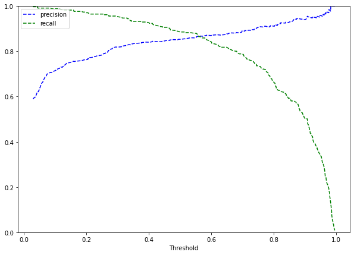

```python
y_scores = lg7.predict(X_train7)
prec, rec, tre = precision_recall_curve(y_train, y_scores,)


def plot_prec_recall_vs_tresh(precisions, recalls, thresholds):
    plt.plot(thresholds, precisions[:-1], "b--", label="precision")
    plt.plot(thresholds, recalls[:-1], "g--", label="recall")
    plt.xlabel("Threshold")
    plt.legend(loc="upper left")
    plt.ylim([0, 1])


plt.figure(figsize=(10, 7))
plot_prec_recall_vs_tresh(prec, rec, tre)
plt.show()
```

```python
# setting the threshold
optimal_threshold_curve = 0.58
```

### Checking model performance on training set

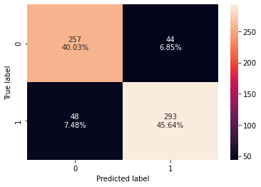

```python
# creating confusion matrix
confusion_matrix_statsmodels(lg7, X_train7, y_train, threshold=optimal_threshold_curve)
```

```python
log_reg_model_train_perf_threshold_curve = model_performance_classification_statsmodels(
    lg7, X_train7, y_train, threshold=optimal_threshold_curve
)
print("Training performance:")
log_reg_model_train_perf_threshold_curve
```

```
Training performance:
```

|  | Accuracy | Recall | Precision | F1 |
| --- | --- | --- | --- | --- |
| 0 | 0.857 | 0.859 | 0.869 | 0.864 |

- Model is performing well on training set.
- Model has given a balanced performance, if the bank wishes to maintain a balance between recall and precision this model can be used.

```python
X_test7 = X_test[list(X_train7.columns)]
```

#### Using model with default threshold

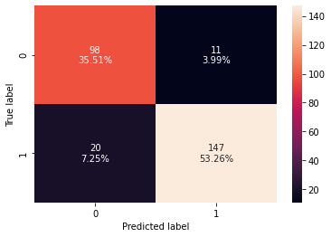

```python
# creating confusion matrix
confusion_matrix_statsmodels(lg7, X_test7, y_test)
```

```python
log_reg_model_test_perf = model_performance_classification_statsmodels(
    lg7, X_test7, y_test
)

print("Test performance:")
log_reg_model_test_perf
```

```
Test performance:
```

|  | Accuracy | Recall | Precision | F1 |
| --- | --- | --- | --- | --- |
| 0 | 0.888 | 0.880 | 0.930 | 0.905 |

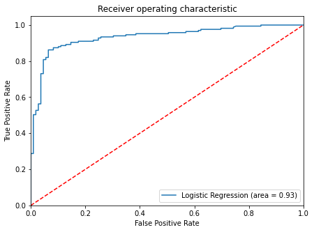

```python
# ROC curve on test set

logit_roc_auc_train = roc_auc_score(y_test, lg7.predict(X_test7))
fpr, tpr, thresholds = roc_curve(y_test, lg7.predict(X_test7))
plt.figure(figsize=(7, 5))
plt.plot(fpr, tpr, label="Logistic Regression (area = %0.2f)" % logit_roc_auc_train)
plt.plot([0, 1], [0, 1], "r--")
plt.xlim([0.0, 1.0])
plt.ylim([0.0, 1.05])
plt.xlabel("False Positive Rate")
plt.ylabel("True Positive Rate")
plt.title("Receiver operating characteristic")
plt.legend(loc="lower right")
plt.show()
```

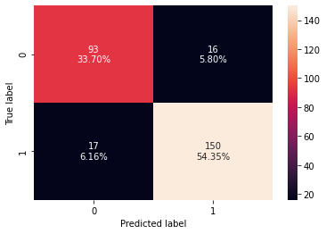

```python
# Using model with threshold=0.41

# creating confusion matrix
confusion_matrix_statsmodels(lg7, X_test7, y_test, threshold=optimal_threshold_auc_roc)
```

```python
# checking model performance for this model
log_reg_model_test_perf_threshold_auc_roc = model_performance_classification_statsmodels(
    lg7, X_test7, y_test, threshold=optimal_threshold_auc_roc
)
print("Test performance:")
log_reg_model_test_perf_threshold_auc_roc
```

```
Test performance:
```

|  | Accuracy | Recall | Precision | F1 |
| --- | --- | --- | --- | --- |
| 0 | 0.880 | 0.898 | 0.904 | 0.901 |

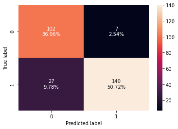

```python
#Using model with threshold = 0.58

# creating confusion matrix
confusion_matrix_statsmodels(lg7, X_test7, y_test, threshold=optimal_threshold_curve)
```

```python
log_reg_model_test_perf_threshold_curve = model_performance_classification_statsmodels(
    lg7, X_test7, y_test, threshold=optimal_threshold_curve
)
print("Test performance:")
log_reg_model_test_perf_threshold_curve
```

```
Test performance:
```

|  | Accuracy | Recall | Precision | F1 |
| --- | --- | --- | --- | --- |
| 0 | 0.877 | 0.838 | 0.952 | 0.892 |